# The aims of science and an open science controversy at US EPA

**D. J. Hicks** (they/them), Emilio Lobato, Cosmo Campbell, and Joseph Dad

University of California, Merced

[figure not shown]

tinyurl.com/25y8hn8h

# *Strengthening Transparency in Regulatory Science*

## *Strengthening Transparency in Regulatory Science*

- Strong open science rule at USEPA
- First Trump administration
- Proposed in 2018, briefly adopted in January 2021
- Based on Secret Science Act, industry complaints about public health studies

## Public comments on ST

- Notice and Comment process
  - Required under Administrative Procedure Act (1946)
  - Submitted by mail, email, or web form
  - Almost always made available on [regulations.gov](https://www.regulations.gov/) →  
    Easy to retrieve for text mining
- Public comments on ST
  - ~1M counting very granularly
  - ~21k as grouped on regulations.gov
  - Opponents generally political liberals
  - Supporters generally political conservatives

## Example comment: Opponent

Im writing to speak out AGAINST your proposed regulations to assault the EPAs use of science in the middle of a global public health crisis.

Peer-reviewed studies assessing the effects of pollution exposure on humans, based on actual personal health data which by law must be kept confidential are among the best science available to the Agency. The misguided proposal would direct EPA to ignore these data unless those confidential personal health data were made publicly available.

This is both unnecessary and impractical. As a retired scientist, I urge you to abandon this reckless plan, for the sake of our childrens health. To do otherwise is unconscionable.

https://www.regulations.gov/comment/EPA-HQ-OA-2018-0259-19410

## Example comment: Supporter

I sincerely hope that you can distance the EPA agency from politically correct science. The only way to do this is to adopt the following methodology.

The scientific method demands that researchers’ work be fully transparent.

Data must be made available for examination.

Theories must be open to challenge.

Disproven theories must be altered or set aside.

Barriers must be removed that would prevent valid conclusions from rising to the top.

I for one am tired of hearing about how bad technologies are for the planet, without any scientific proof that things today are different. Don’t tell me that glarciers are melting and the ocean is rising a foot every 10 years. Remove yourselves from such statements and give facts about such a change: volume of water, how will it be measured, what could be causing it, what can be done that is both environmentally and economically sound.

https://www.regulations.gov/comment/EPA-HQ-OA-2018-0259-12305

## Text mining methods

- 21k comments is too many to analyze using traditional close reading
- 800 comments categorized as supporting/opposing by humans
- remaining comments categorized using machine learning model
- natural language processing (NLP) to extract adjective-noun pairs
- keyword searches that account for synonyms and related concepts

# Aims of science

## Rival views of the aims of science

- Two views of the aims of science
- Differ over relationship between epistemic and pragmatic aims

**narrow view**

Science has only epistemic aims;  
practical applications are at best nice side effects,  
must not override epistemic considerations

**broad view**

Science has both epistemic and pragmatic aims;  
relationship between the two is complex, context-dependent;  
pragmatic considerations can take priority in some cases

## Rival views in ST public comments

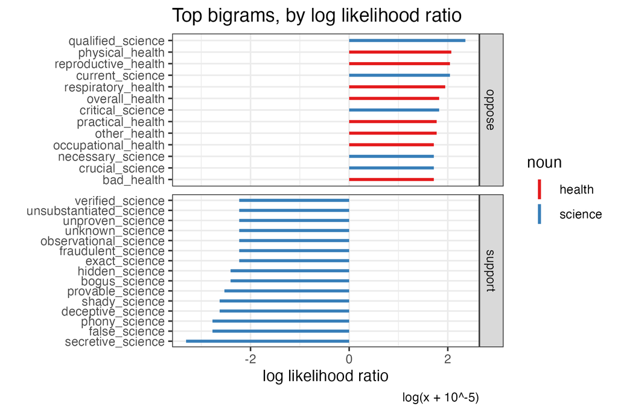

## Rival views in ST public comments

Opponents (liberals) use broad view

Supporters (conservatives) use narrow view

- Both epistemic & pragmatic aims
- Public health as a primary aim of EPA/regulatory science
- ST would frustrate that aim
- Epistemic aims only; almost no discussion of practical concerns
- EPA/regulatory science as currently failing to achieve its epistemic aims
- ST would promote them

# Upshots

## Rival views as deep disagreement

In the ST controversy, disagreement over the aims of science is **deep** in two senses:

**axiomatic; self-evident**

Each side treats their view as not in need of justification or defense

**latent**

Neither side seems to recognize the existence of disagreement

Just like shared background assumptions can underpin consensus,  
unshared background assumptions can underpin disagreement

## Cynicism and “Gold Standard Science”

For supporters of ST, science is

- secretive
- false
- phony
- deceptive
- shady
- bogus
- hidden
- fraudulent

Cynical frame for interpreting science

- Also shared by the mainstream science reform movement!
- ST weaponized the rhetoric of this movement (Hicks 2023)
- Continued in the May 23, 2025, EO calling for a “return” to “Gold Standard Science” (Tollefson and Garisto 2025)

# References

Hicks, Daniel J. 2012. “Scientific Practices and Their Social Context.” U. of Notre Dame.

———. 2023. “Open Science, the Replication Crisis, and Environmental Public Health.” *Accountability in Research* 30 (1): 34–62. https://doi.org/10.1080/08989621.2021.1962713.

Tollefson, Jeff, and Dan Garisto. 2025. “Trump’s Call for ‘Gold Standard Science’ Has Prompted an Outcry: Here’s Why.” *Nature*, May. https://doi.org/10.1038/d41586-025-01668-x.